# Getting started with hrfdecoder

## Goal

Learn how to fit an HRF-aware weakly supervised decoder to fMRI time series data and make predictions on new data.

## TL;DR

```r
library(hrfdecode)
library(fmridesign)

# Fit decoder from fMRI timeseries and event onsets
fit <- fit_hrfdecoder(
  Y = fmri_data,           # T × V matrix (time × voxels)
  event_model = ev_model,  # event_model from fmridesign
  baseline_model = bl_model
)

# Predict on new data
preds <- predict(fit, newdata = test_data, mode = "trial")
```

## Introduction

Traditional MVPA requires trial-averaged data or explicit trial labels. The `hrfdecode` package takes a different approach: it learns directly from continuous fMRI time series and event timing information. This “weakly supervised” approach jointly estimates:

1. **Soft labels** — continuous trial-level predictions
2. **HRF parameters** — subject-specific hemodynamic response
3. **Decoder weights** — multivariate classification function

All three components are optimized together using alternating least squares.

## Setup

```r
library(hrfdecode)
library(fmridesign)
```

For this tutorial, we’ll create synthetic data that mimics a simple two-class decoding experiment.

```r
# Simulation parameters
n_trs <- 200        # Number of time points
n_voxels <- 50      # Number of voxels
n_trials <- 40      # Number of trials
tr <- 2             # TR in seconds

# Create event table (onset times and conditions)
onsets <- seq(10, n_trs * tr - 20, length.out = n_trials)
conditions <- rep(c("A", "B"), each = n_trials / 2)

event_table <- data.frame(
  onset = onsets,
  condition = conditions,
  duration = 1
)

head(event_table)
```

```
#>      onset condition duration
#> 1 10.00000         A        1
#> 2 19.48718         A        1
#> 3 28.97436         A        1
#> 4 38.46154         A        1
#> 5 47.94872         A        1
#> 6 57.43590         A        1
```

Next, we define the experimental design using the `fmridesign` package.

```r
# Create event model from event table
  ev_model <- event_model(
  onset ~ hrf(condition, basis = "spmg1"),
  data = event_table,
  block = ~ 1,
  sampling_frame = fmrihrf::sampling_frame(TR = tr, blocklens = n_trs)
)

# Create baseline model (intercept + linear drift)
  bl_model <- baseline_model(basis = "bs", degree = 3, sframe = fmrihrf::sampling_frame(TR = tr, blocklens = n_trs))
```

Now simulate fMRI data with signal in a subset of voxels.

```r
# Generate synthetic BOLD data
# First half of voxels discriminate condition A vs B
true_pattern <- c(rep(1, n_voxels / 2), rep(0, n_voxels / 2))

# Build TR-grid stick functions per condition
stick_A <- rep(0, n_trs)
stick_B <- rep(0, n_trs)
idx_A <- pmin(n_trs, pmax(1L, floor(event_table$onset[event_table$condition == "A"] / tr) + 1L))
idx_B <- pmin(n_trs, pmax(1L, floor(event_table$onset[event_table$condition == "B"] / tr) + 1L))
stick_A[idx_A] <- 1
stick_B[idx_B] <- 1
signal <- stick_A - stick_B

# Convolve with HRF (SPMG2 basis) sampled at TR grid
hrf_obj <- fmrihrf::getHRF("spmg2")
span <- attr(hrf_obj, "span") %||% 24
K <- max(1L, ceiling(span / tr))
tgrid <- seq(0, (K - 1L) * tr, by = tr)
hrf_basis <- fmrihrf::evaluate(hrf_obj, tgrid)
hrf_vec <- as.numeric(hrf_basis %*% c(1, 0))
signal_conv <- stats::convolve(signal, rev(hrf_vec), type = "open")[1:n_trs]

# Add to random noise
Y_train <- matrix(rnorm(n_trs * n_voxels, sd = 1), n_trs, n_voxels)
for (v in 1:n_voxels) {
  Y_train[, v] <- Y_train[, v] + signal_conv * true_pattern[v] * 0.5
}

dim(Y_train)
```

```
#> [1] 200  50
```

## Fitting the decoder

Now we fit the decoder using `fit_hrfdecoder()`. The key arguments are:

```r
fit <- fit_hrfdecoder(
  Y = Y_train,
  ev_model = ev_model,
  base_model = bl_model,
  lambda_W = 0.1,
  max_iter = 10,
  verbose = FALSE
)

# Inspect fit object
class(fit)
```

```
#> [1] "hrfdecoder_fit"
```

```r
names(fit)
```

```
#>  [1] "W"           "P"           "b"           "theta"       "hrf"
#>  [6] "conditions"  "background"  "converged"   "iterations"  "settings"
#> [11] "train"       "preproc"     "diagnostics"
```

## Inspecting decoder weights

Let’s examine which voxels contribute most to the decoder.

```r
# Get top 10 voxels by absolute weight
top_voxels <- order(abs(fit$W), decreasing = TRUE)[1:10]
top_weights <- fit$W[top_voxels]

data.frame(
  voxel = top_voxels,
  weight = round(top_weights, 3),
  true_pattern = true_pattern[top_voxels]
)
```

[output not shown]

## Making predictions

The `predict()` method supports two modes:

1. **“tr”** — TR-level predictions (one per time point)
2. **“trial”** — Trial-level predictions (aggregated across event duration)

```r
# Create test data (new noise, same signal)
Y_test <- matrix(rnorm(n_trs * n_voxels, sd = 1), n_trs, n_voxels)
for (v in 1:n_voxels) {
  Y_test[, v] <- Y_test[, v] + signal_conv * true_pattern[v] * 0.5
}

# TR-level predictions
pred_tr <- predict(fit, newdata = Y_test, mode = "tr")
nrow(pred_tr)  # One prediction per TR
```

```
#> [1] 200
```

```r
# Trial-level predictions (aggregated within event windows)
pred_trial <- predict(fit, newdata = Y_test, ev_model_test = ev_model, mode = "trial")
nrow(pred_trial$probs)  # One prediction per trial
```

```
#> [1] 40
```

Trial-level predictions aggregate the TR-level signal using HRF-weighted averaging within each event window.

## Evaluating performance

For a two-class problem, we can compute classification accuracy.

```r
# Convert event-level probabilities to class predictions
true_labels <- ifelse(conditions == "A", 1, -1)
pred_classes <- ifelse(pred_trial$probs[, 1] >= pred_trial$probs[, 2], 1, -1)

# Accuracy
accuracy <- mean(pred_classes == true_labels)
cat("Classification accuracy:", round(accuracy * 100, 1), "%\n")
```

```
#> Classification accuracy: 100 %
```

## Visualizing predictions

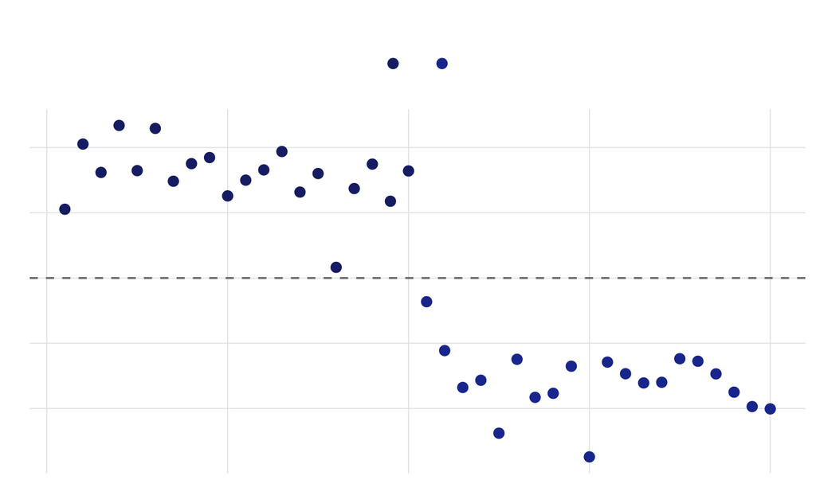

Trial-level predictions vs. true condition labels. Positive values indicate condition A, negative values condition B.

```r
if (requireNamespace("ggplot2", quietly = TRUE)) {
  library(ggplot2)

  plot_df <- data.frame(
    trial = 1:n_trials,
    prediction = as.numeric(pred_trial$probs[, 1] - pred_trial$probs[, 2]),
    true_label = true_labels,
    condition = conditions
  )

  scl <- if (requireNamespace("albersdown", quietly = TRUE)) {
    albersdown::scale_color_albers(params$family)
  } else {
    ggplot2::scale_color_discrete()
  }

  ggplot(plot_df, aes(x = trial, y = prediction, color = condition)) +
    geom_point(size = 2.5) +
    geom_hline(yintercept = 0, linetype = "dashed", color = "gray50") +
    scl +
    labs(
      title = "Trial-level decoder predictions",
      subtitle = "Weakly supervised decoder correctly separates conditions",
      x = "Trial number",
      y = "Soft label prediction",
      color = "Condition"
    )
}
```

## Next steps

This tutorial covered the basics of fitting and predicting with `hrfdecode`. For more advanced topics:

- AR Prewhitening — Handle temporal autocorrelation in multi-run data
- rMVPA Integration — Run searchlight analysis with cross-validation
- HRF Estimation — Understand joint HRF learning and event aggregation
- Weakly Supervised Learning — Deep dive into the ALS algorithm